# Forecasting Section 7.8

Seema Rani Kanuri

May 01, 2017

# Question 1:

Data set books contains the daily sales of paperback and hardcover books at the same store. The task is to forecast the next four days’ sales for paperback and hardcover books (data set books).

### a. Plot the series and discuss the main features of the data.

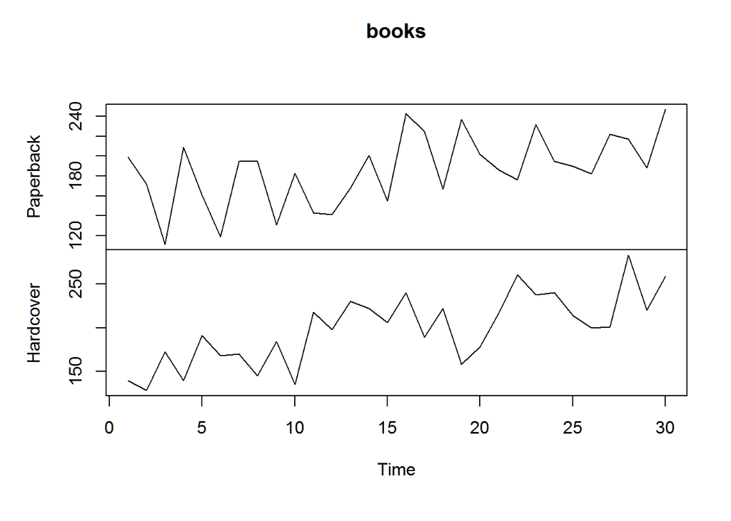

```r
books <- books
plot(books)
```

Both types of book have a positive trend and both show fairly large fluctations in daily sales. This may be due to sales spiking at certain periods of the week, probably at weekends.

```r
pb <- books[,1]
```

```r
fit1 <- ses(pb, initial='simple', varalpha=0.2, h=3)
sum((pb - fitted(fit1))) #51.94
```

```
## [1] 52.48527
```

```r
fit2 <- ses(pb, initial='simple', varalpha=0.4, h=3)
sum((pb - fitted(fit2))) #50.28
```

```
## [1] 52.48527
```

```r
fit3 <- ses(pb, initial='simple', varalpha=0.6, h=3)
sum((pb - fitted(fit3))) #47.45
```

```
## [1] 52.48527
```

```r
fit4 <- ses(pb, initial='simple', varalpha=0.8, h=3)
sum((pb - fitted(fit4))) #46.67
```

```
## [1] 52.48527
```

```r
fit5 <- ses(pb, initial='simple', varalpha=0.9, h=3)
sum((pb - fitted(fit5))) #47.10 - previous sse was smaller so choose smaller varalpha.
```

```
## [1] 52.48527
```

```r
fit6 <- ses(pb, initial='simple', varalpha=0.85, h=3)
sum((pb - fitted(fit6))) #46.82 - previous sse was smaller so choose smaller varalpha.
```

```
## [1] 52.48527
```

```r
fit7 <- ses(pb, initial='simple', varalpha=0.83, h=3)
sum((pb - fitted(fit7))) #46.74 - previous sse was smaller so choose smaller varalpha.
```

```
## [1] 52.48527
```

```r
fit8 <- ses(pb, initial='simple', varalpha=0.82, h=3)
sum((pb - fitted(fit8))) #46.71 - previous sse was smaller so choose smaller varalpha.
```

```
## [1] 52.48527
```

```r
fit9 <- ses(pb, initial='simple', varalpha=0.81, h=3)
sum((pb - fitted(fit9))) #46.69 - previous sse was smaller so choose smaller varalpha.
```

```
## [1] 52.48527
```

```r
fit10 <- ses(pb, initial='simple', varalpha=0.75, h=3)
sum((pb - fitted(fit10))) #46.66 - new minimum found.
```

```
## [1] 52.48527
```

```r
fit11 <- ses(pb, initial='simple', varalpha=0.3, h=3)
sum((pb - fitted(fit11))) #52.24
```

```
## [1] 52.48527
```

```r
fit12 <- ses(pb, initial='simple', varalpha=0.5, h=3)
sum((pb - fitted(fit12))) #48.62
```

```
## [1] 52.48527
```

```r
fit13 <- ses(pb, initial='simple', varalpha=1, h=3)
sum((pb - fitted(fit13))) #48
```

```
## [1] 52.48527
```

```r
varalpha <- c(0.2, 0.4, 0.6, 0.8, 0.9, 0.85, 0.83, 0.82, 0.81, 0.75, 0.3, 0.5, 1)
sse <- c(51.94, 50.28, 47.45, 46.67, 47.10, 46.82, 46.74, 46.71, 46.68, 46.66, 52.24, 48.62, 48)
```

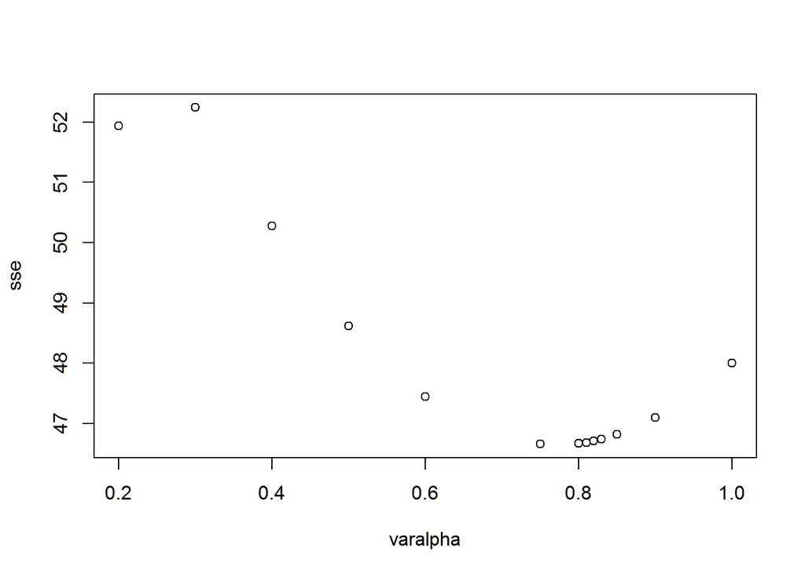

```r
plot(varalpha, sse)
```

```r
fit1 <- ses(pb, initial='simple', h=4)
fit2 <- ses(pb, initial='simple', varalpha=0.75, h=4)
```

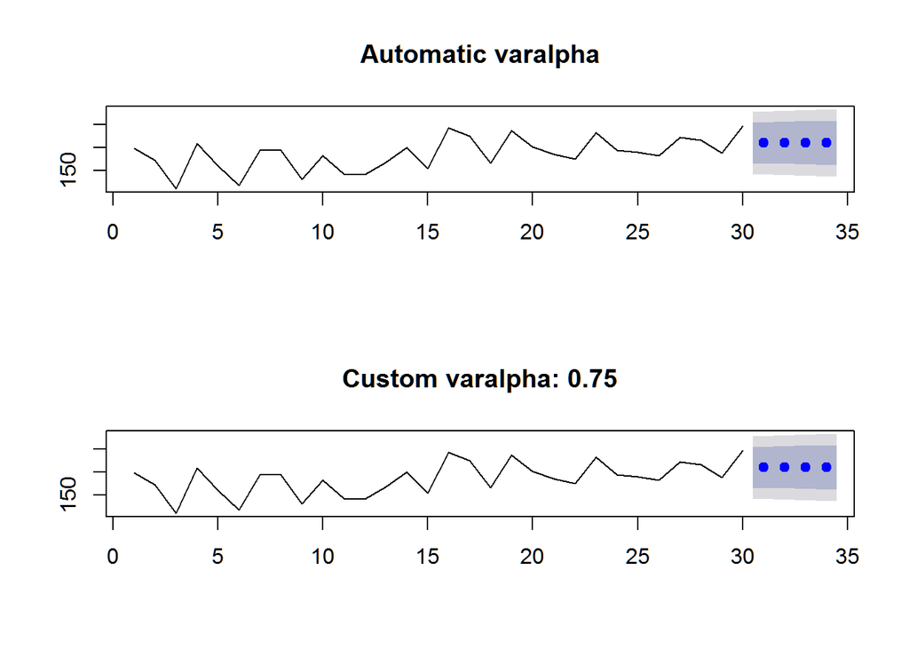

```r
par(mfrow=c(2,1))
plot(fit1, main="Automatic varalpha")
plot(fit2, main="Custom varalpha: 0.75")
```

### d. Repeat but with initial=“optimal”. How much difference does an optimal initial level make?

```r
fit3 <- ses(pb, initial='optimal', h=4)
sum((pb - fitted(fit3)))
```

```
## [1] 215.2864
```

The model is more pessimistic than the others and has a higher SSE.

### e. Repeat steps (b)-(d) with the hardcover series.

```r
hb <- books[,2]
```

```r
fit1 <- ses(hb, initial='simple', varalpha=0.8, h=3)
sum((hb - fitted(fit1))) #142.59
```

```
## [1] 291.8856
```

```r
fit2 <- ses(hb, initial='simple', varalpha=0.2, h=3)
sum((hb - fitted(fit2))) #465.09
```

```
## [1] 291.8856
```

```r
fit3 <- ses(hb, initial='simple', varalpha=0.9, h=3)
sum((hb - fitted(fit3))) #129.61
```

```
## [1] 291.8856
```

```r
fit4 <- ses(hb, initial='simple', varalpha=0.5, h=3)
sum((hb - fitted(fit4))) #213.47
```

```
## [1] 291.8856
```

```r
fit5 <- ses(hb, initial='simple', varalpha=0.95, h=3)
sum((hb - fitted(fit5))) #124.42
```

```
## [1] 291.8856
```

```r
fit6 <- ses(hb, initial='simple', varalpha=0.97, h=3)
sum((hb - fitted(fit6))) #122.56
```

```
## [1] 291.8856
```

```r
fit7 <- ses(hb, initial='simple', varalpha=0.99, h=3)
sum((hb - fitted(fit7))) #120.82
```

```
## [1] 291.8856
```

```r
fit8 <- ses(hb, initial='simple', varalpha=1, h=3)
sum((hb - fitted(fit8))) #120
```

```
## [1] 291.8856
```

```r
varalpha <- c(1, 0.99, 0.97, 0.95, 0.5, 0.9, 0.2, 0.8)
sse <- c(120, 120.82, 122.56, 124.42, 213.47, 129.61, 465.09, 142.59)
```

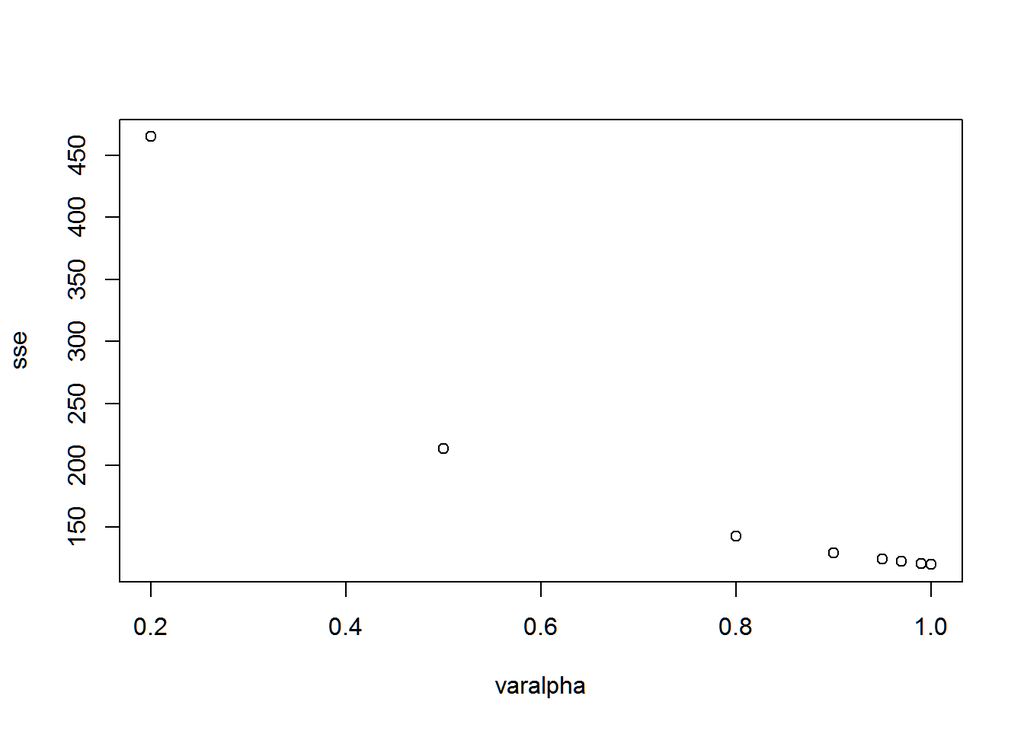

```r
plot(varalpha, sse)
```

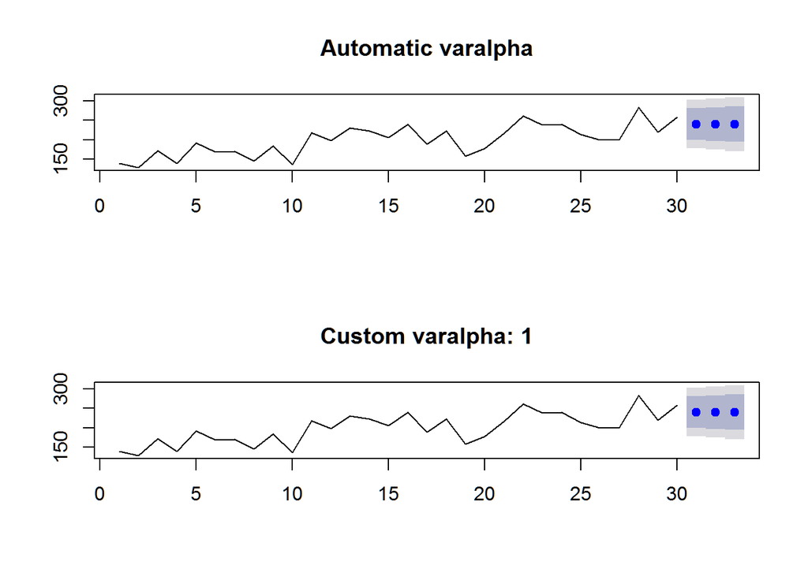

```r
par(mfrow=c(2,1))
plot(fit1, main="Automatic varalpha")
plot(fit2, main="Custom varalpha: 1")
```

```r
fit3 <- ses(hb, initial='optimal', h=4)
sum((hb - fitted(fit3)))
```

```
## [1] 275.0075
```

Setting the intial paramater to ‘optimal’ gives very similar results to ‘simple’.

# Question 2:

Apply Holt’s linear method to the paperback and hardback series and compute four-day forecasts in each case.

### a. Compare the SSE measures of Holt’s method for the two series to those of simple exponential smoothing in the previous question. Discuss the merits of the two forecasting methods for these data sets.

```r
books
```

```
## Time Series:
## Start = 1
## End = 30
## Frequency = 1
##    Paperback Hardcover
##  1       199       139
##  2       172       128
##  3       111       172
##  4       209       139
##  5       161       191
##  6       119       168
##  7       195       170
##  8       195       145
##  9       131       184
## 10       183       135
```

[output cut: 20 more lines]

```r
dev.off()
```

```r
fit15 <- holt(books[,1], initial = "simple", h=4)
```

```r
summary(fit15)
```

```
##
## Forecast method: Holt's method
##
## Model Information:
## Holt's method
##
## Call:
##  holt(y = books[, 1], h = 4, initial = "simple")
##
##   Smoothing parameters:
##     alpha = 0.2984
##     beta  = 0.4984
##
##   Initial states:
##     l = 199
##     b = -27
##
##   sigma:  39.5463
## Error measures:
##                    ME     RMSE     MAE      MPE     MAPE      MASE
## Training set 7.769844 39.54634 33.5377 1.633306 18.19621 0.8457332
##                    ACF1
## Training set -0.1088681
##
## Forecasts:
##    Point Forecast     Lo 80    Hi 80     Lo 95    Hi 95
## 31       222.0201 171.33940 272.7007 144.51068 299.5295
## 32       229.6904 146.75742 312.6233 102.85537 356.5254
## 33       237.3606 114.30837 360.4129  49.16842 425.5529
## 34       245.0309  75.80702 414.2548 -13.77470 503.8366
```

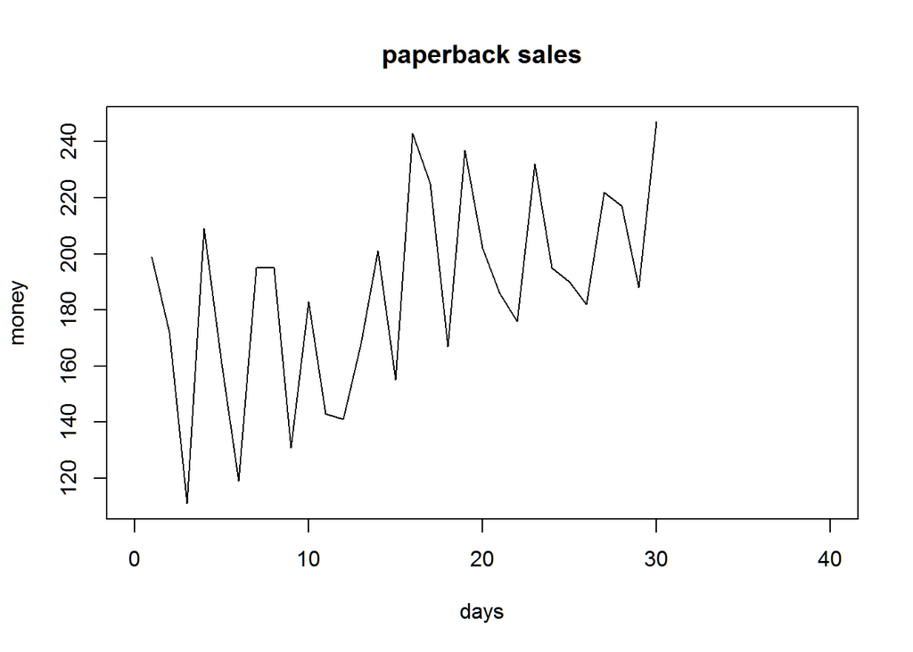

```r
plot(books[,1], main="paperback sales", xlab="days", ylab="money", xlim=c(0,40))
```

```r
#lines(fitted(fit15), col="red", type="o")
#lines(fit15$mean, col="green", type="o")
```

```r
fit15<- holt(books[,1], initial = "optimal", h=4)
```

```r
summary(fit15)
```

```
##
## Forecast method: Holt's method
##
## Model Information:
## Holt's method
##
## Call:
##  holt(y = books[, 1], h = 4, initial = "optimal")
##
##   Smoothing parameters:
##     alpha = 1e-04
##     beta  = 1e-04
##
##   Initial states:
##     l = 174.6003
##     b = 1.0606
##
##   sigma:  31.6618
##
##      AIC     AICc      BIC
## 319.3427 321.8427 326.3486
##
## Error measures:
##                     ME     RMSE     MAE       MPE     MAPE      MASE
## Training set -4.458116 31.66184 26.4503 -6.029264 15.84609 0.6670076
##                    ACF1
## Training set -0.1444935
##
## Forecasts:
##    Point Forecast    Lo 80    Hi 80    Lo 95    Hi 95
## 31       207.0380 166.4617 247.6143 144.9820 269.0941
## 32       208.0853 167.5090 248.6615 146.0292 270.1413
## 33       209.1325 168.5562 249.7088 147.0764 271.1886
## 34       210.1797 169.6034 250.7560 148.1236 272.2358
```

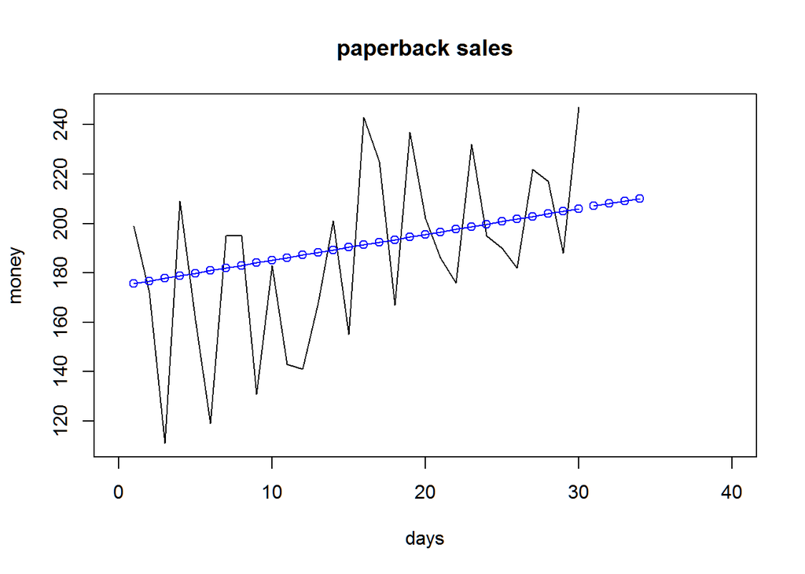

```r
plot(books[,1], main="paperback sales", xlab="days", ylab="money", xlim=c(0,40))
lines(fitted(fit15), col="blue", type="o")
lines(fit15$mean, col="blue", type="o")
```

### b. Compare the forecasts for the two series using both methods. Which do you think is best?

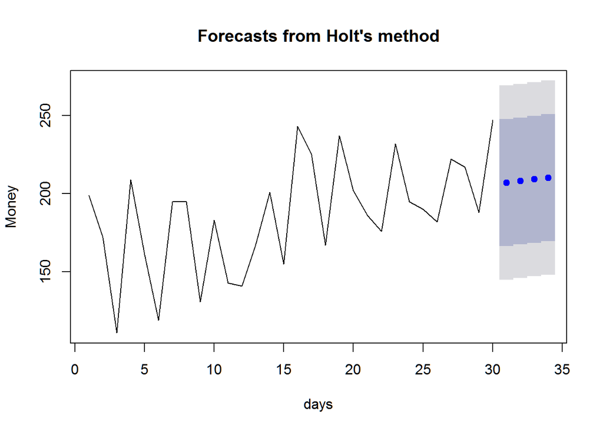

```r
plot(fit15, xlab="days", ylab= "Money")
```

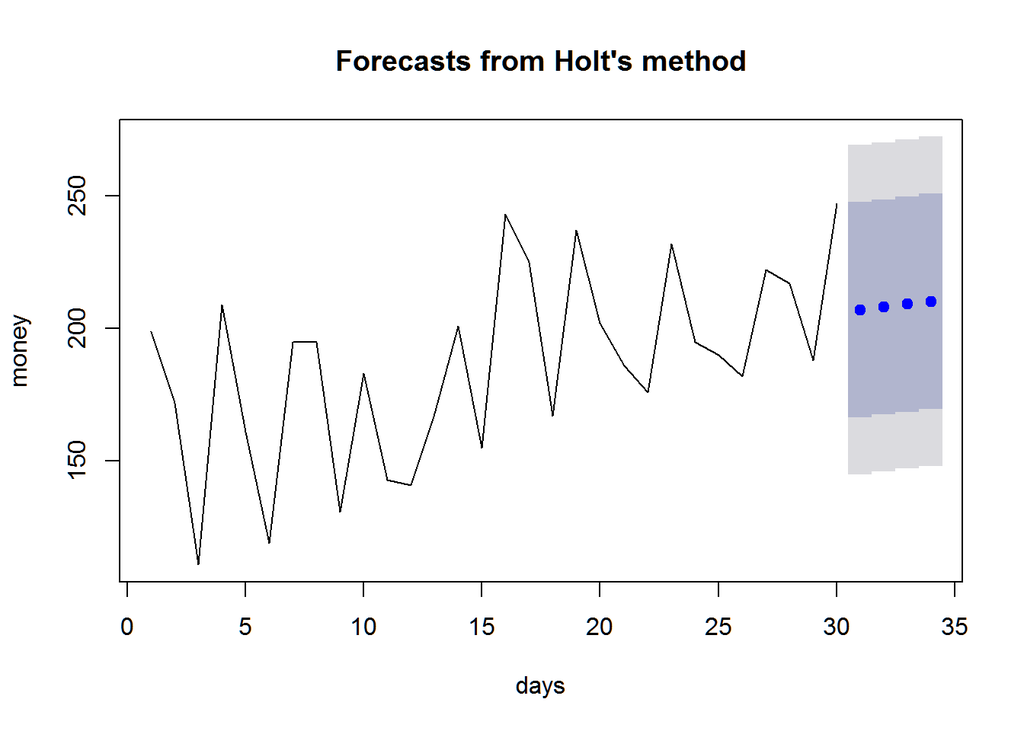

```r
plot(fit15, xlab="days", ylab="money")
```

### c. Calculate a 95% prediction interval for the first forecast for each series using both methods, assuming normal errors. Compare your forecasts with those produced by R.

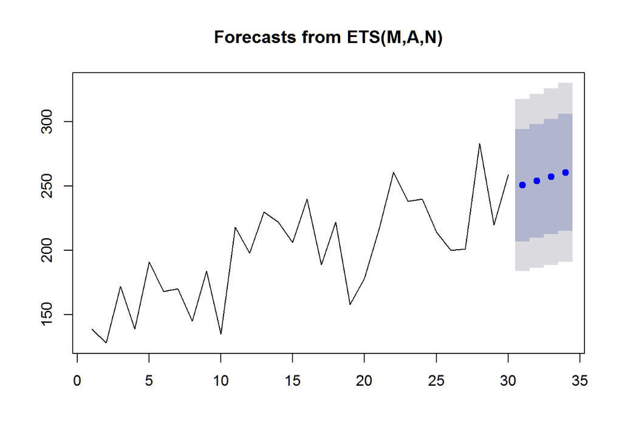

```r
etshb <- ets(hb)
plot(forecast(etshb, h=4))
```

# Question 3:

For this exercise, use the quarterly UK passenger vehicle production data from 1977:1–2005:1 (data set ukcars).

### a. Plot the data and describe the main features of the series.

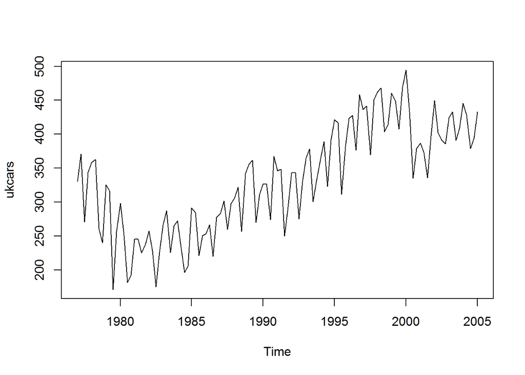

```r
cars <- ukcars
plot(ukcars)
```

There is a strong seasonal effect throughout the series. The trend was declining until the early 80s then it started increasing until 2000. Production recovered in a year or two.

### b. Decompose the series using STL and obtain the seasonally adjusted data.

```r
decomposed <- stl(cars, s.window="periodic", robust=TRUE)
seasonal <- decomposed$time.series[,1]
cars_sa <- cars - seasonal
```

### c. Forecast the next two years of the series using an additive damped trend method applied to the seasonally adjusted data. Then reseasonalize the forecasts. Record the parameters of the method and report the RMSE of the one-step forecasts from your method.

```r
fit <- holt(cars_sa, h=8, damped = TRUE)
lastyear <- rep(decomposed$time.series[110:113,"seasonal"],2)
reseasonalized_fc <- fit$mean + lastyear
```

```r
summary(fit)
```

```
##
## Forecast method: Damped Holt's method
##
## Model Information:
## Damped Holt's method
##
## Call:
##  holt(y = cars_sa, h = 8, damped = TRUE)
##
##   Smoothing parameters:
##     alpha = 0.5666
##     beta  = 3e-04
##     phi   = 0.9117
##
##   Initial states:
##     l = 346.0865
##     b = -9.7583
##
##   sigma:  25.2032
##
##      AIC     AICc      BIC
## 1275.490 1276.283 1291.854
##
## Error measures:
##                    ME     RMSE     MAE       MPE     MAPE      MASE
## Training set 2.518454 25.20318 20.5804 0.3038991 6.585405 0.6707052
##                   ACF1
## Training set 0.0353549
##
## Forecasts:
##         Point Forecast    Lo 80    Hi 80    Lo 95    Hi 95
## 2005 Q2       407.4117 375.1125 439.7109 358.0144 456.8090
## 2005 Q3       407.4110 370.2796 444.5425 350.6234 464.1987
## 2005 Q4       407.4104 366.0038 448.8170 344.0845 470.7364
## 2006 Q1       407.4099 362.1274 452.6924 338.1563 476.6635
## 2006 Q2       407.4094 358.5554 456.2634 332.6936 482.1251
## 2006 Q3       407.4089 355.2254 459.5924 327.6011 487.2167
## 2006 Q4       407.4085 352.0939 462.7230 322.8122 492.0048
## 2007 Q1       407.4081 349.1291 465.6871 318.2780 496.5382
```

### d. Forecast the next two years of the series using Holt’s linear method applied to the seasonally adjusted data. Then reseasonalize the forecasts. Record the parameters of the method and report the RMSE of of the one-step forecasts from your method.

```r
fit2 <- holt(cars_sa, h=8)
reseasonalized_fc <- fit$mean + lastyear
```

```r
summary(fit)
```

```
##
## Forecast method: Damped Holt's method
##
## Model Information:
## Damped Holt's method
##
## Call:
##  holt(y = cars_sa, h = 8, damped = TRUE)
##
##   Smoothing parameters:
##     alpha = 0.5666
##     beta  = 3e-04
##     phi   = 0.9117
##
##   Initial states:
##     l = 346.0865
##     b = -9.7583
##
##   sigma:  25.2032
##
##      AIC     AICc      BIC
## 1275.490 1276.283 1291.854
##
## Error measures:
##                    ME     RMSE     MAE       MPE     MAPE      MASE
## Training set 2.518454 25.20318 20.5804 0.3038991 6.585405 0.6707052
##                   ACF1
## Training set 0.0353549
##
## Forecasts:
##         Point Forecast    Lo 80    Hi 80    Lo 95    Hi 95
## 2005 Q2       407.4117 375.1125 439.7109 358.0144 456.8090
## 2005 Q3       407.4110 370.2796 444.5425 350.6234 464.1987
## 2005 Q4       407.4104 366.0038 448.8170 344.0845 470.7364
## 2006 Q1       407.4099 362.1274 452.6924 338.1563 476.6635
## 2006 Q2       407.4094 358.5554 456.2634 332.6936 482.1251
## 2006 Q3       407.4089 355.2254 459.5924 327.6011 487.2167
## 2006 Q4       407.4085 352.0939 462.7230 322.8122 492.0048
## 2007 Q1       407.4081 349.1291 465.6871 318.2780 496.5382
```

### e. Now use ets() to choose a seasonal model for the data.

```r
fit3 <- ets(cars_sa)
```

### g. Compare the forecasts from the two approaches? Which seems most reasonable?

```r
predict(ets(cars_sa))
```

```
##         Point Forecast    Lo 80    Hi 80    Lo 95    Hi 95
## 2005 Q2       407.2388 374.8231 439.6546 357.6632 456.8145
## 2005 Q3       407.2388 369.2421 445.2355 349.1279 465.3498
## 2005 Q4       407.2388 364.3819 450.0958 341.6948 472.7829
## 2006 Q1       407.2388 360.0193 454.4584 335.0228 479.4549
## 2006 Q2       407.2388 356.0270 458.4507 328.9171 485.5606
## 2006 Q3       407.2388 352.3242 462.1535 323.2541 491.2235
## 2006 Q4       407.2388 348.8557 465.6219 317.9496 496.5281
## 2007 Q1       407.2388 345.5821 468.8956 312.9430 501.5347
```

# Question 4:

For this exercise, use the monthly Australian short-term overseas visitors data, May 1985–April 2005. (Data set: visitors.)

### a. Make a time plot of your data and describe the main features of the series.

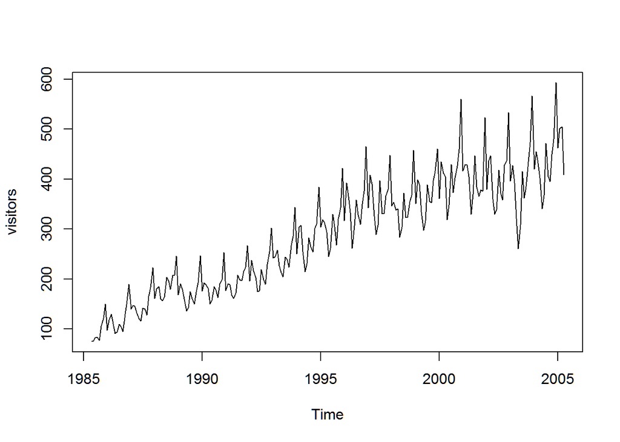

```r
plot(visitors)
```

There is a positive linear trend, seasonality throughout the series and increasing variance.

### b. Forecast the next two years using Holt-Winters’ multiplicative method.

```r
two_years <- hw(visitors, h=24, seasonal='multiplicative')
```

### c. Why is multiplicative seasonality necessary here?

It is necessary because the plot shows that the variance increases through the series.

### d. Experiment with making the trend exponential and/or damped.

```r
two_years1 <- hw(visitors, h=24, seasonal='multiplicative', damped=TRUE)
two_years2 <- hw(visitors, h=24, seasonal='multiplicative', exponential=TRUE)
```

### e. Compare the RMSE of the one-step forecasts from the various methods. Which do you prefer?

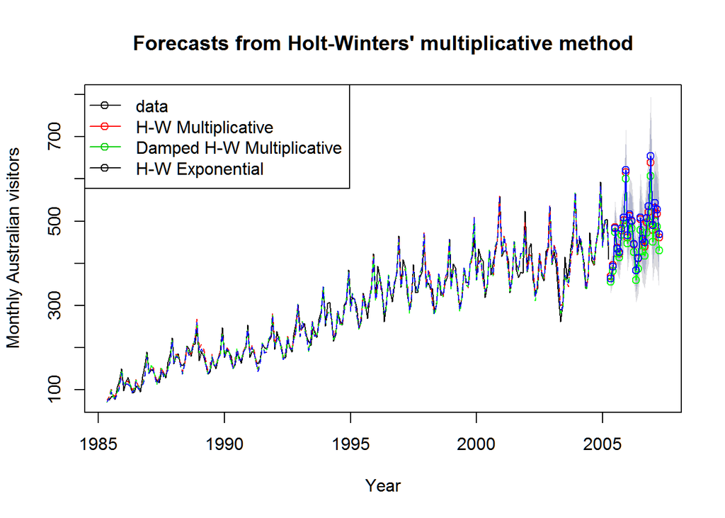

```r
plot(two_years,ylab="Monthly Australian visitors", plot.conf=FALSE,
     fcol="white", xlab="Year")
lines(fitted(two_years), col="red", lty=2)
lines(fitted(two_years1), col="green", lty=2)
lines(fitted(two_years2), col='blue', lty=2)
lines(two_years$mean, type="o", col="red")
lines(two_years1$mean, type="o", col="green")
lines(two_years2$mean, type="o", col="blue")
legend("topleft",lty=1, pch=1, col=1:3,
       c("data","H-W Multiplicative", 'Damped H-W Multiplicative',
         'H-W Exponential'))
```

### f. Now fit each of the following models to the same data:

#### (i) a multiplicative Holt-Winters’ method;

```r
fit1 <- holt(visitors, seasonal='multiplicative')
```

#### (ii) an ETS model;

```r
fit2 <- ets(visitors)
```

#### (iii) an additive ETS model applied to a Box-Cox transformed series;

```r
lambda <- BoxCox.lambda(visitors)
boxcox_visitors <- BoxCox(visitors, lambda)
fit3 <- ets(boxcox_visitors, model='AAZ')
```

#### (iv) a seasonal naive method applied to the Box-Cox transformed series;

```r
fit4 <- snaive(boxcox_visitors)
```

#### (v) an STL decomposition applied to the Box-Cox transformed data followed by an ETS model applied to the seasonally adjusted (transformed) data.

```r
decomposed <- decompose(boxcox_visitors)
seasonal_visitors <- decomposed$seasonal

fit5 <- ets(seasonal_visitors)
```

## g. For each model, look at the residual diagnostics and compare the forecasts for the next two years. Which do you prefer?

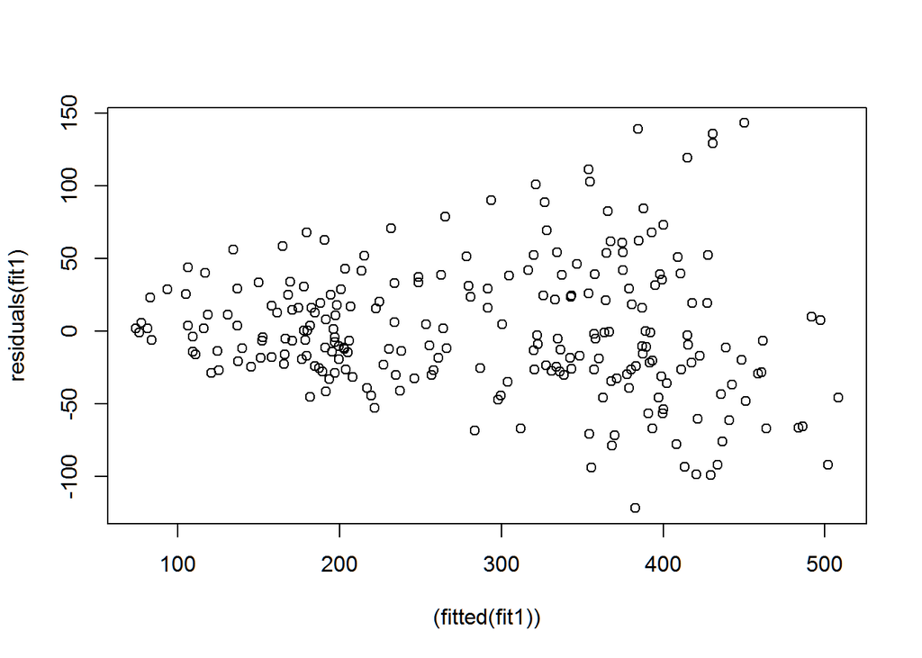

```r
plot((fitted(fit1)), residuals(fit1))
```

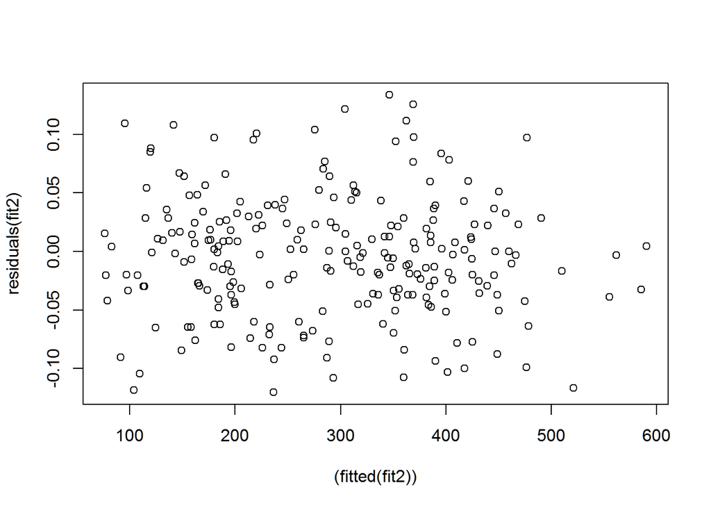

```r
# Unbiased and heteroskedastic.

plot((fitted(fit2)), residuals(fit2))
```

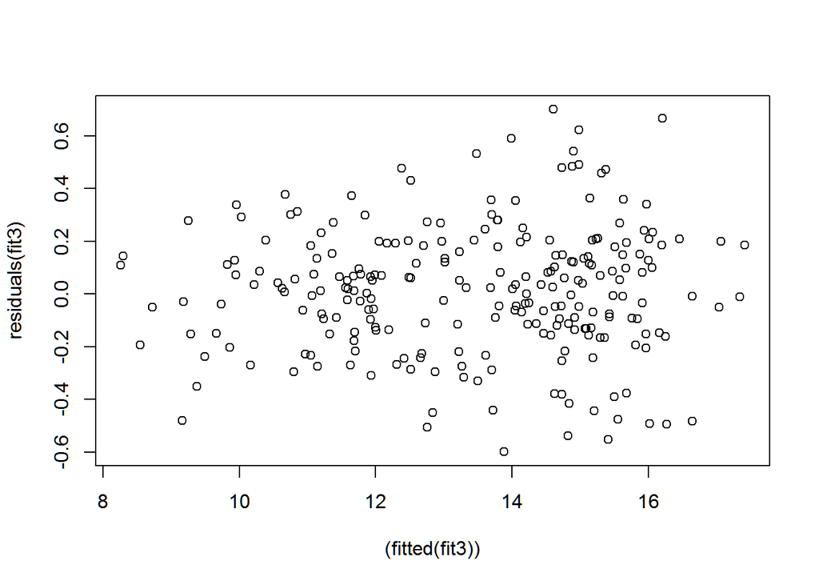

```r
# Unbiased and homoskedastic.

plot((fitted(fit3)), residuals(fit3))
```

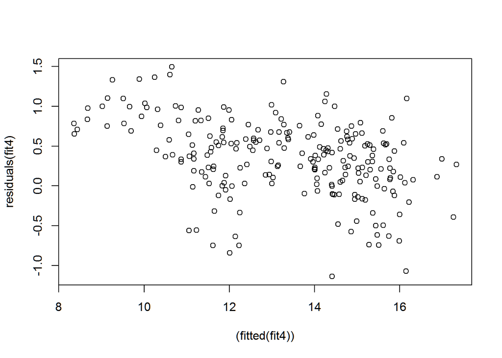

```r
# Slightly biased and borderline heteroskedastic.

plot((fitted(fit4)), residuals(fit4))
```

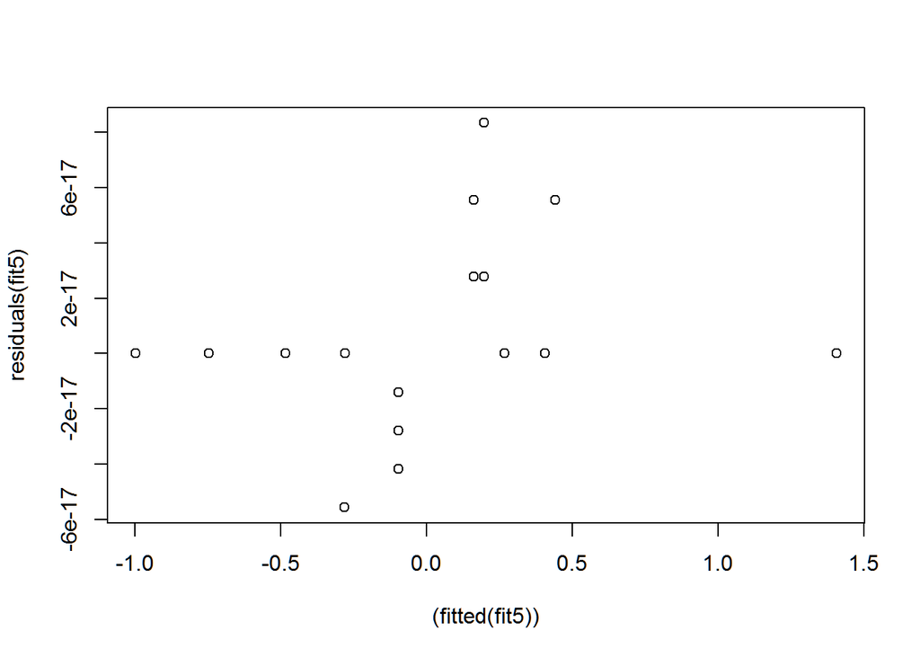

```r
# Biased and heteroskedastic.

plot((fitted(fit5)), residuals(fit5))
```

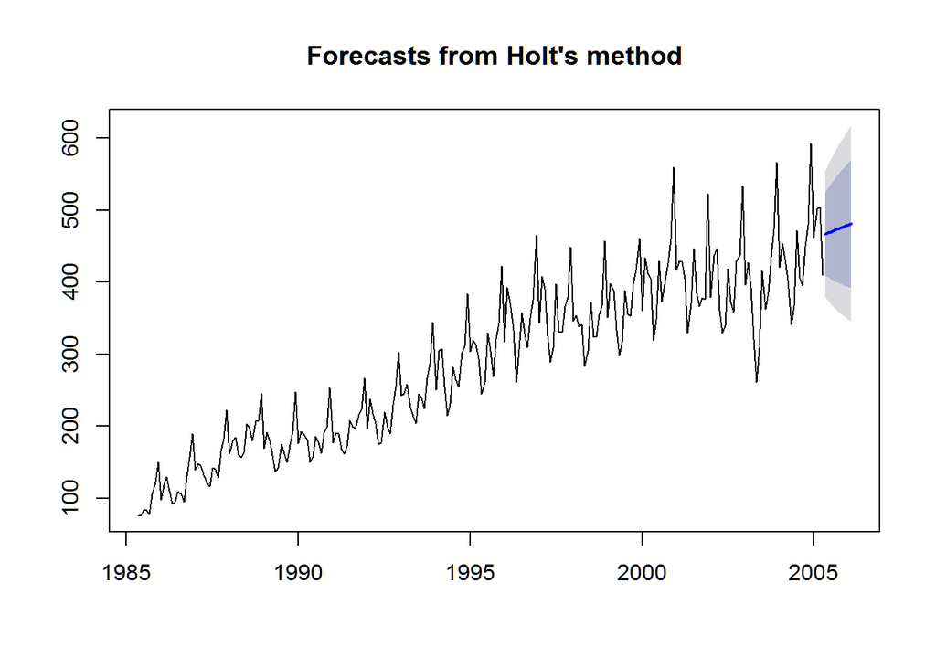

```r
# Biased and heteroskedastic.

plot(forecast(fit1, h=10))
```

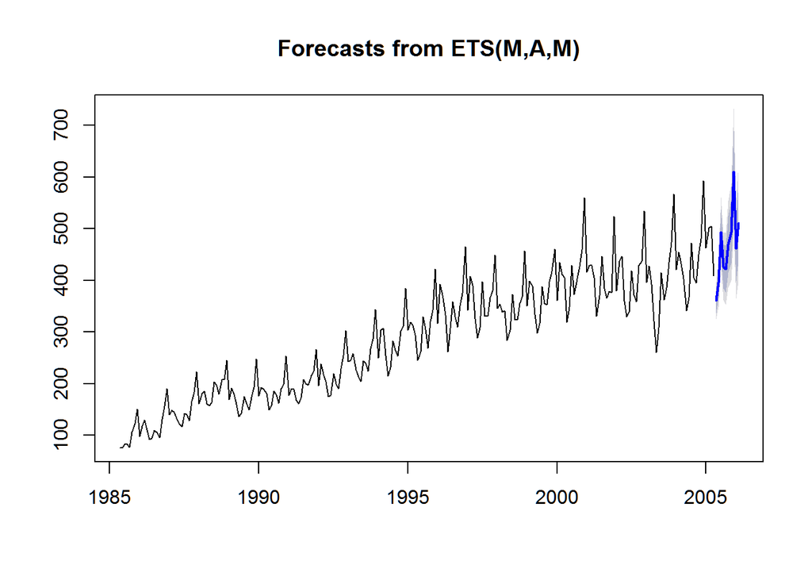

```r
plot(forecast(fit2, h=10))
```

The second model (ETS) has the best looking residual plot and it’s forecasts appear plausible (as does fit 1 but fit 1 has heteroskedasticity present in the residuals.)